# PLS_contaminantes_meteo

2025-05-26

#PLS

```r
library(readr)
library(dplyr)
library(lubridate)
library(tidyr)
library(tableone)
```

```r
calidad_meteo <- read_csv("calidad_meteo.csv")
calidad_meteo <- calidad_meteo %>%
  mutate(
    wind_x = `Velocidad del viento (Km/h)` * cos(`Ángulo del viento (°)` * pi/180),
    wind_y = `Velocidad del viento (Km/h)` * sin(`Ángulo del viento (°)` * pi/180)
  )
```

```r
# 1) Instala y carga el paquete pls

library(pls)
# 2) Prepara tus datos: selecciona X (meteorología) e Y (contaminantes)
datos_pls <- calidad_meteo %>%
  select(
    # Predictores meteorológicos
    Temperatura,
    `Precipitaciones ( mm)`,
    `Humedad (%)`,
    `Velocidad del viento (Km/h)`,
    `Ráfaga de viento (Km/h)`,
    `Nubosidad (%)`,
    `Visibilidad ( Km)`,
    wind_x, wind_y,
    # Respuesta: contaminantes
    NO, NO2, NOx, O3, PM10, `PM2.5`, SO2
  ) %>%
  na.omit()  # elimina filas con NA

# 3) Ajusta el modelo PLSR
#    - formula: varias Y ~ todas las X
#    - ncomp: número máximo de componentes a estimar
#    - scale = TRUE: centra y escala internamente
#    - validation = "CV": validación cruzada v-fold (por defecto 10-fold)
set.seed(123)
pls_fit <- plsr(
  cbind(NO, NO2, NOx, O3, PM10, `PM2.5`, SO2) ~
    Temperatura + `Precipitaciones ( mm)` + `Humedad (%)` +
    `Velocidad del viento (Km/h)` + `Ráfaga de viento (Km/h)` +
    `Nubosidad (%)` + `Visibilidad ( Km)` +
    wind_x + wind_y,
  data       = datos_pls,
  ncomp      = 9,
  scale      = TRUE,
  validation = "CV"
)

# 4) Explora resultados
summary(pls_fit)           # varianza explicada en X y Y por comp.
```

```
## Data:    X dimension: 289956 9
##  Y dimension: 289956 7
## Fit method: kernelpls
## Number of components considered: 9
##
## VALIDATION: RMSEP
## Cross-validated using 10 random segments.
##
## Response: NO
##        (Intercept)  1 comps  2 comps  3 comps  4 comps  5 comps  6 comps
## CV           14.72    14.61    14.56    14.48    14.42    14.41    14.41
## adjCV        14.72    14.61    14.56    14.48    14.42    14.41    14.41
##        7 comps  8 comps  9 comps
## CV       14.41     14.4     14.4
## adjCV    14.41     14.4     14.4
##
## Response: NO2
##        (Intercept)  1 comps  2 comps  3 comps  4 comps  5 comps  6 comps
## CV           15.97    15.55    15.37    15.25    15.13    15.12    15.12
## adjCV        15.97    15.55    15.37    15.25    15.13    15.12    15.12
##        7 comps  8 comps  9 comps
## CV       15.12    15.12    15.12
## adjCV    15.12    15.12    15.12
##
## Response: NOx
##        (Intercept)  1 comps  2 comps  3 comps  4 comps  5 comps  6 comps
## CV           35.17    34.59    34.33    34.06    33.84    33.81    33.81
## adjCV        35.17    34.59    34.33    34.06    33.84    33.81    33.81
##        7 comps  8 comps  9 comps
## CV       33.81     33.8     33.8
## adjCV    33.81     33.8     33.8
##
## Response: O3
##        (Intercept)  1 comps  2 comps  3 comps  4 comps  5 comps  6 comps
## CV           26.56    22.67    22.44     22.1    22.08    22.01    22.01
## adjCV        26.56    22.67    22.44     22.1    22.08    22.01    22.01
##        7 comps  8 comps  9 comps
## CV       21.97    21.93    21.93
## adjCV    21.97    21.93    21.93
##
```

[output cut: 28 more lines]

```
## NO2     5.1602   7.3153   8.7634  10.1814  10.2991  10.3009  10.3017  10.3018
## NOx     3.2420   4.7195   6.2075   7.4221   7.5718   7.5753   7.5835   7.6171
## O3     27.1410  28.5974  30.7959  30.8870  31.3137  31.3170  31.5850  31.8398
## PM10    0.7694   2.0119   2.0138   2.0320   2.0320   2.5710   2.7779   3.1452
## PM2.5   7.5271   9.0214  10.4413  10.4489  10.5099  10.5994  10.6886  10.8759
## SO2     0.1246   0.3515   0.3525   0.3559   0.3719   0.3925   0.3925   0.4008
##         9 comps
## X      100.0000
## NO       4.2583
## NO2     10.3052
## NOx      7.6189
## O3      31.8408
## PM10     3.1535
## PM2.5   10.9301
## SO2      0.4064
```

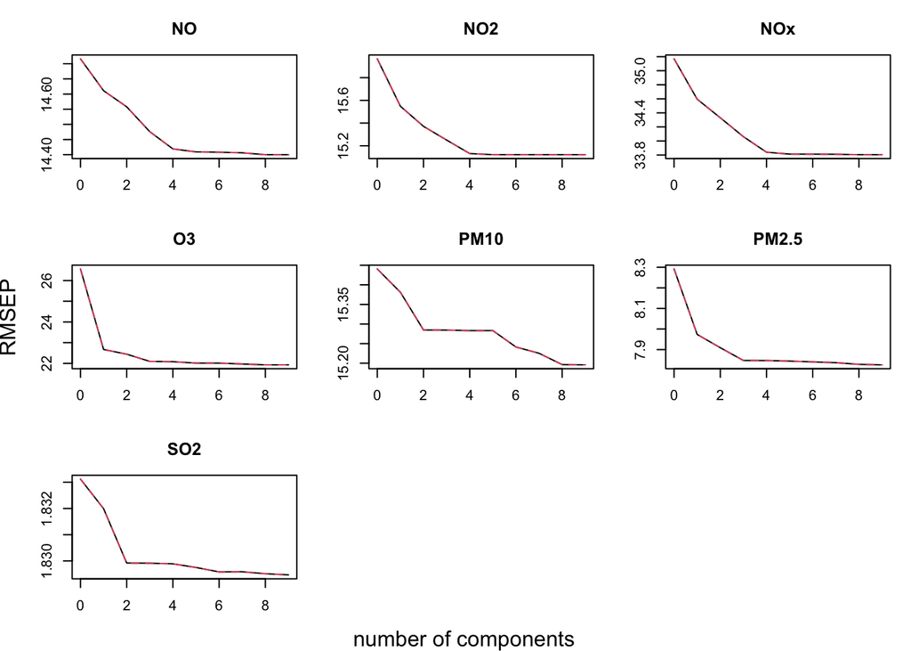

```r
validationplot(pls_fit)    # gráfico de RMSEP vs n.º de componentes
```

```r
opt_ncomp = 3
```

```r
# 1) Extraer coeficientes para el nº óptimo de componentes
coefs_raw <- coef(pls_fit, ncomp = opt_ncomp)

# Si viniera en 3D (pred × resp × comp), simplificamos al plano X–Y:
if (length(dim(coefs_raw)) == 3) {
  coefs <- coefs_raw[ , , 1]   # componente elegido
} else {
  coefs <- coefs_raw
}

# 2) Convertir a data.frame para manejarlo mejor
pred_names <- dimnames(coefs)[[1]]
resp_names <- dimnames(coefs)[[2]]
coef_df <- as.data.frame(coefs)
rownames(coef_df) <- pred_names
colnames(coef_df) <- resp_names

# 3) Para cada contaminante, ordena las variables por peso absoluto
list_pesos <- lapply(resp_names, function(resp) {
  vec <- coef_df[[resp]]
  # orden descendente en valor absoluto
  orden <- order(abs(vec), decreasing = TRUE)
  data.frame(
    variable = pred_names[orden],
    coef     = vec[orden],
    row.names = NULL
  )
})
names(list_pesos) <- resp_names

# 4) Mostrar en consola con título y kable
for (resp in resp_names) {
  cat("#### Contaminante:", resp, "\n\n")
  print(
    knitr::kable(
      list_pesos[[resp]],
      caption = paste("Coeficientes PLS para", resp)
    )
  )
  cat("\n\n")
}
```

```
## #### Contaminante: NO
##
##
##
## Table: Coeficientes PLS para NO
##
## |variable                      |       coef|
## |:-----------------------------|----------:|
## |Temperatura                   | -1.5497323|
## |`Humedad (%)`                 | -1.0598996|
## |`Velocidad del viento (Km/h)` | -0.9784040|
## |wind_x                        | -0.8556850|
## |`Ráfaga de viento (Km/h)`     | -0.8016656|
## |`Nubosidad (%)`               | -0.7639182|
## |wind_y                        | -0.4163515|
## |`Precipitaciones ( mm)`       | -0.2133774|
## |`Visibilidad ( Km)`           |  0.2128608|
##
##
## #### Contaminante: NO2
##
##
##
## Table: Coeficientes PLS para NO2
##
## |variable                      |       coef|
## |:-----------------------------|----------:|
## |Temperatura                   | -2.5357546|
## |`Velocidad del viento (Km/h)` | -1.9709145|
## |`Ráfaga de viento (Km/h)`     | -1.6881067|
## |`Humedad (%)`                 | -1.3353515|
## |wind_x                        | -1.3303509|
## |`Nubosidad (%)`               | -1.1546097|
## |wind_y                        | -0.5369357|
## |`Precipitaciones ( mm)`       | -0.4225488|
## |`Visibilidad ( Km)`           |  0.3666334|
##
##
## #### Contaminante: NOx
##
```

[output cut: 76 more lines]

```
##
##
## Table: Coeficientes PLS para SO2
##
## |variable                      |       coef|
## |:-----------------------------|----------:|
## |`Ráfaga de viento (Km/h)`     | -0.0468283|
## |`Velocidad del viento (Km/h)` | -0.0428002|
## |wind_x                        | -0.0328303|
## |Temperatura                   | -0.0286266|
## |`Humedad (%)`                 | -0.0215724|
## |`Nubosidad (%)`               | -0.0199118|
## |wind_y                        |  0.0197766|
## |`Precipitaciones ( mm)`       | -0.0122110|
## |`Visibilidad ( Km)`           |  0.0086900|
```

Convención usada para el viento: • wind y > 0 → sopla desde el este (brisa de mar). • wind x > 0 → sopla desde el norte.

Coeficientes con valor absoluto ≳ 0,5 son los realmente influyentes. NO

El NO sube en noches frías y secas con aire poco movido. Temperatura negativa (-1.55) indica máximos con frío; humedad negativa (-1.06) refuerza la acumulación en ambientes secos. Viento medio (-0.98) y ráfagas (-0.80) negativos muestran que la calma favorece el gas; basta algo de ventilación para dispersarlo. El término wind x (-0.86) implica que los vientos del sur (wind x < 0) –típicos de brisas terrales débiles– dan los mayores picos. Nubosidad negativa (-0.76) confirma que cielos despejados, con inversión térmica, concentran el NO.

NO₂ Patrón calcado pero todavía más marcado: temperatura (-2.54), viento (-1.97), ráfaga (-1.69), humedad (-1.34), wind x (-1.33) y nubosidad (-1.15). Las mismas noches frías, secas y en calma (sobre todo con débil flujo sur) disparan el NO₂ . NOx La suma NO+NO₂ depende esencialmente de los mismos factores, con coeficientes aún mayores (-4.9 a -2.3). Queda claro que la combinación de fuerte emisión y mala dispersión gobierna los picos.

O₃ El ozono se comporta al revés que los NOₓ. Temperatura muy positiva (+8.29): calor = fotólisis y producción de O₃. wind y positivo (+6.22) indica que la brisa marina (desde el este) inyecta aire enriquecido en ozono y radicales. La ventilación horizontal y vertical también ayuda (velocidad +5.40, ráfaga +2.90). Humedad negativa (-1.03) muestra que días muy húmedos frenan la fotólisis y destruyen radicales, reduciendo el O₃.

PM10

Las partículas gruesas bajan con viento y suben con calma. Ráfaga (-0.95) y velocidad (-0.88) dominan. wind x (-0.63) vuelve a señalar que flujo sur favorece la acumulación urbana,(trae polvo de áfrica); temperatura negativa (-0.57) asocia aire frío y estable a polvo retenido.

PM2.5 La fracción fina es muy sensible a la ventilación: velocidad (-1.14) y ráfaga (-1.10) fuertes la diluyen. Destaca humedad positiva (+0.66): la formación secundaria de sulfatos y nitratos se acelera en atmósfera húmeda. El resto de variables quedan por debajo del umbral de importancia.

SO₂ Ningún coeficiente meteorológico supera |0.05|. Las concentraciones de SO₂ dependen casi por completo de las emisiones puntuales (buques, industria) más que del estado del tiempo.